# Yellow River Marsh Aquatic Preserve

### Restored

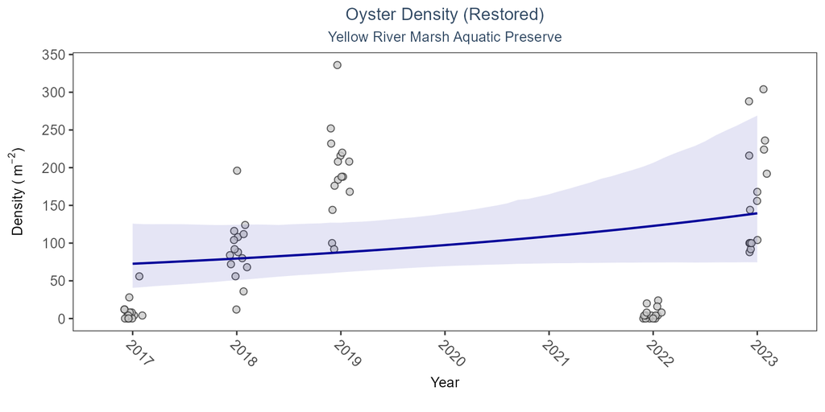

Scatter plot of oyster density over time. If the time series included five or more years with observations, an estimated trend (blue line) and a 95% credible interval (purple band) may also be plotted. Data points are jittered horizontally to reduce overlap.

Model results for Oyster Density - Restored

| Habitat Type | Shell Type | Statistical Trend | Period of Record | Estimate | Standard Error | Credible Interval |
| --- | --- | --- | --- | --- | --- | --- |
| Restored | Live Oysters | No detectable trend | 2017 - 2023 | 11.14 | 10.11 | -4.62 to 35.87 |

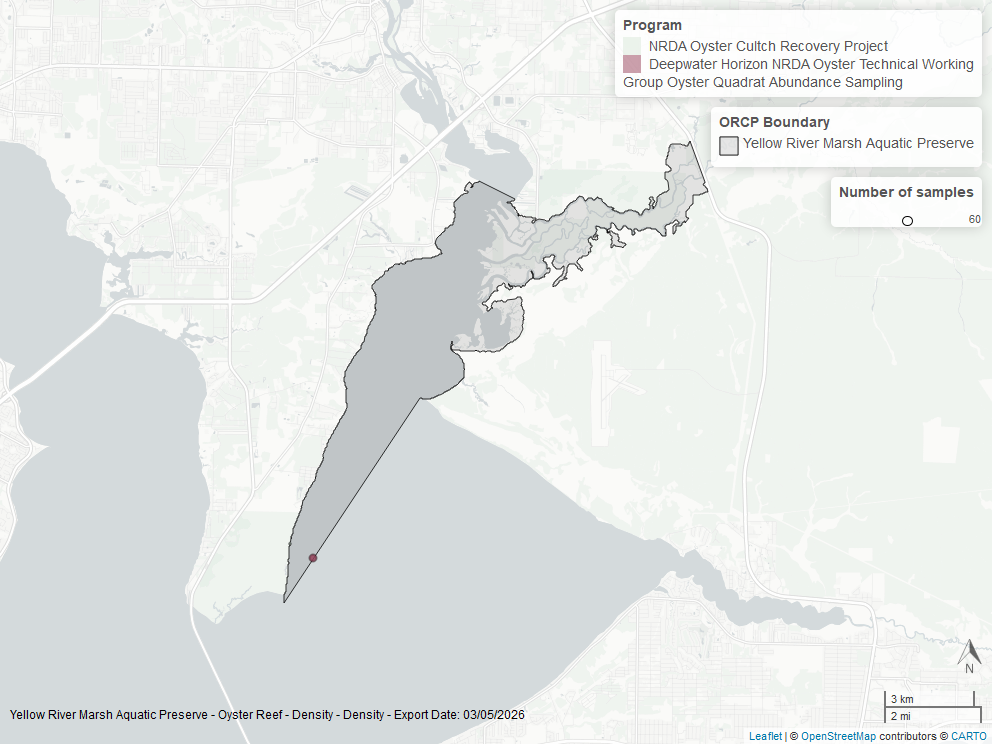

Map showing location of oyster density sampling locations within the boundaries of *Yellow River Marsh Aquatic Preserve*. The bubble size on the maps above reflect the amount of data available at each sampling site.

## Percent Live

For restored reefs, percent live cover increased by an average of 6.75% per year.

### Restored

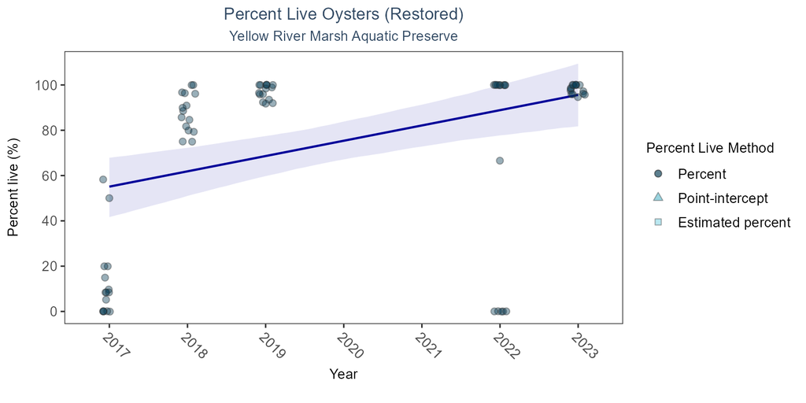

Scatter plot of percent live oysters over time. If the time series included five or more years with observations, an estimated trend (blue line) and a 95% credible interval (purple band) may also be plotted. Estimation method is represented as percent (circles), point-intercept (triangle), or estimated percent (square), with data points jittered horizontally to reduce overlap.

Model results for Oyster Percent Live - Restored

| Habitat Type | Shell Type | Statistical Trend | Period of Record | Estimate | Standard Error | Credible Interval |
| --- | --- | --- | --- | --- | --- | --- |
| Restored | Live Oysters | Increasing trend | 2017 - 2023 | 6.75 | 1.81 | 3.24 to 10.43 |

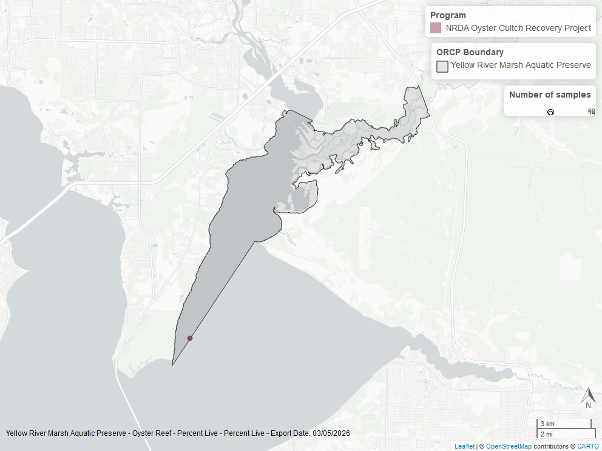

Map showing location of oyster percent live sampling locations within the boundaries of *Yellow River Marsh Aquatic Preserve*. The bubble size on the maps above reflect the amount of data available at each sampling site.

## Shell Height

For natural reefs, there was insufficient data to calculate a trend for live oysters in either the 25-75mm or the ≥75mm size class. For restored reefs, annual average live oyster shell height in the 25-75mm size class increased by 0.33mm per year, and there was insufficient data to calculate a trend for live oysters in the ≥75mm size class.

### Natural

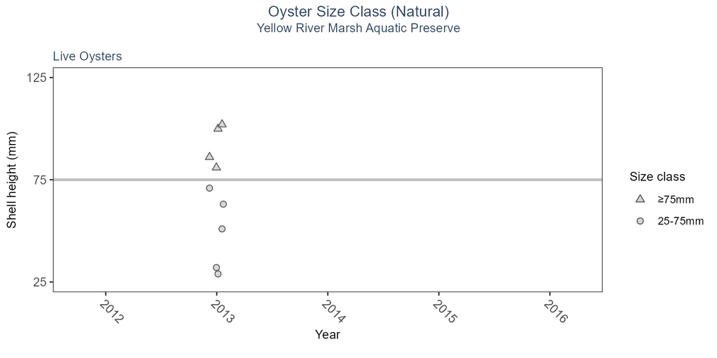

Model results for Oyster Shell Height - Natural

| Habitat Type | Shell Type | SizeClass | Statistical Trend | Period of Record | No. of Samples | Estimate | Standard Error | Credible Interval |
| --- | --- | --- | --- | --- | --- | --- | --- | --- |
| Natural | Live Oysters | >75mm | Insufficient data | 2013 - 2013 | 4 | - | - | - |
| Natural | Live Oysters | 25-75mm | Insufficient data | 2013 - 2013 | 5 | - | - | - |

### Restored

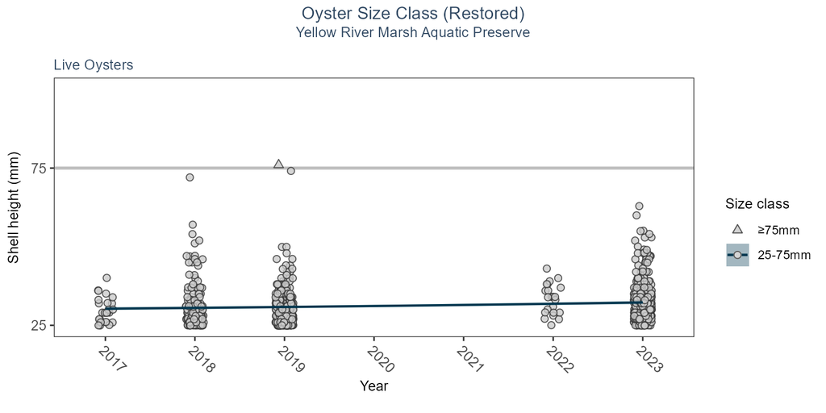

Model results for Oyster Shell Height - Restored

| Habitat Type | Shell Type | SizeClass | Statistical Trend | Period of Record | No. of Samples | Estimate | Standard Error | Credible Interval |
| --- | --- | --- | --- | --- | --- | --- | --- | --- |
| Restored | Live Oysters | >75mm | Insufficient data | 2019 - 2019 | 1 | - | - | - |
| Restored | Live Oysters | 25-75mm | Increasing trend | 2017 - 2023 | 993 | 0.33 | 0.08 | 0.18 to 0.48 |

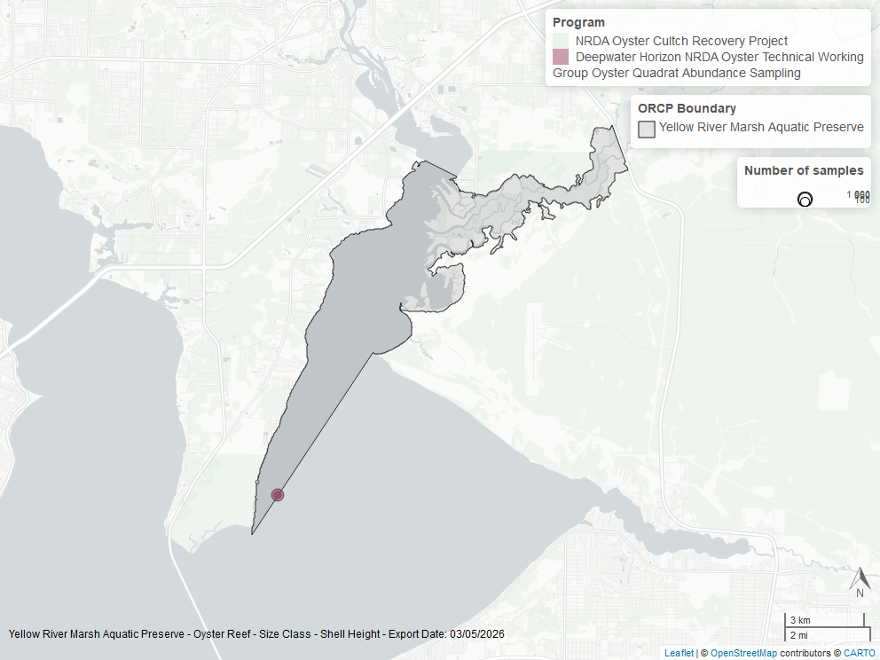

Map showing location of oyster shell height sampling locations within the boundaries of *Yellow River Marsh Aquatic Preserve*. The bubble size on the maps above reflect the amount of data available at each sampling site.

# References

1.

U.S. Environmental Protection Agency (EPA); Gulf Ecology Division. [Pensacola Bay Water Quality Monitoring Program](https://data.florida-seacar.org/programs/details/505). (2016).

2.

Florida Department of Environmental Protection (DEP). [Florida STORET / WIN](https://data.florida-seacar.org/programs/details/5002). (2024).

3.

Florida Department of Agriculture and Consumer Services (FDACS) - Division of Aquaculture. [Shellfish Harvest Area Classification Program](https://data.florida-seacar.org/programs/details/540). (2022).

4.

University of Florida (UF); Institute of Food and Agricultural Sciences. [Florida LAKEWATCH Program](https://data.florida-seacar.org/programs/details/514). (2024).

5.

U.S. Environmental Protection Agency (EPA). [EPA STOrage and RETrieval Data Warehouse (STORET)/WQX](https://data.florida-seacar.org/programs/details/103). (2023).

6.

U.S. Environmental Protection Agency (EPA); Office of Research and Development. [Environmental Monitoring Assessment Program](https://data.florida-seacar.org/programs/details/115). (2004).

7.

U.S. Environmental Protection Agency (EPA); Office of Water; National Oceanic and Atmospheric Administration (NOAA); U.S. Geological Survey (USGS); U.S. Fish and Wildlife Service (USFWS); National Estuary Program (NEP); coastal states. [National Aquatic Resource Surveys, National Coastal Condition Assessment](https://data.florida-seacar.org/programs/details/118). (2021).

8.

Florida Fish and Wildlife Conservation Commission (FWC). [Fisheries-Independent Monitoring (FIM) Program](https://data.florida-seacar.org/programs/details/69). (2022).

9.

Florida Fish and Wildlife Conservation Commission (FWC); Florida Fish and Wildlife Research Institute (FWRI). [Harmful Algal Bloom Marine Observation Network](https://data.florida-seacar.org/programs/details/95). (2018).

10.

Florida Department of Environmental Protection (DEP); Office of Resilience and Coastal Protection (RCP); Northwest Florida Aquatic Preserves. [Yellow River Marsh Aquatic Preserve Continuous Water Quality Monitoring](https://data.florida-seacar.org/programs/details/467). (2024).